# Data Science for Bioinformatics

# Midterm project on “Drosophila melanogaster Genetic Reference Panel”"

Reference paper describes the data obtained here.

Paper source: The Drosophila melanogaster Genetic Reference Panel, Nature 2012

Data source

- http://dgrp2.gnets.ncsu.edu/ (the project)
- http://dgrp2.gnets.ncsu.edu/data.html (the data source tabular 3)

Tabular formatted genotype (space delimited, 0 = ref allele, 2 = alt allele (not necessarily minor), - = missing)

A zipped version of the data is available in the datasets folder.

Unzipped it is about 2 gigabytes and will probably be too large for your computers memory.

But for speed we recommend that you unzip the data - then work on the unzipped data file!

# Questions on the DRGP dataset

## For the entire report we only focus on variants located on chromosome 3L.

#### Q: Unzip the data, extract all variants located on the chromosome and save the data (write_rds)

```
library(tidyverse)

# The file is already unzipped.
# unzip(zipfile = "../datasets/dataset.02.dgrp2.tgeno.zip", overwrite = T)

f <- function(df, pos) {
  #print(df)

  tt <- df %>%
    select(-c(starts_with('line'))) %>%
    filter(chr == '3L') %>%
    {.}
  #write_csv(tt, "../datasets/dgrp2.3L", append = TRUE) # Log progress to log file

  return(tt)
}

data_file_path = "../datasets/dgrp2.tgeno"

first_2 = read_delim(data_file_path, delim = ' ', n_max = 2)

df_ <- read_delim_chunked(file = data_file_path,
                         callback = ListCallback$new(f),
                         chunk_size = 50000, guess_max = 100,
                         col_names = T, delim = " ", comment = "#",
                         progress = T)
data_3L = bind_rows(df_)

data_3L = data_3L %>% mutate(
  total_l = 205
)
```

#### Q: How many variants do you have ?

```r
summary(data_3L)
```

```
##      chr                 pos                id
##  Length:1001554     Min.   :   19766   Length:1001554
##  Class :character   1st Qu.: 5212911   Class :character
##  Mode  :character   Median :10356914   Mode  :character
##                     Mean   :10536598
##                     3rd Qu.:15310900
##                     Max.   :24535547
##      ref                alt                 refc            altc
##  Length:1001554     Length:1001554     Min.   :  0.0   Min.   :  1.00
##  Class :character   Class :character   1st Qu.:153.0   1st Qu.:  2.00
##  Mode  :character   Mode  :character   Median :192.0   Median :  7.00
##                                        Mean   :168.1   Mean   : 29.32
##                                        3rd Qu.:202.0   3rd Qu.: 37.00
##                                        Max.   :204.0   Max.   :204.00
##       qual          cov            total_l
##  Min.   :999   Min.   :  0.00   Min.   :205
##  1st Qu.:999   1st Qu.: 26.00   1st Qu.:205
##  Median :999   Median : 30.00   Median :205
##  Mean   :999   Mean   : 29.39   Mean   :205
##  3rd Qu.:999   3rd Qu.: 33.00   3rd Qu.:205
##  Max.   :999   Max.   :446.00   Max.   :205
```

A: 1001554

#### Q: Report how many variants have less than 90% of the lines genotyped.

```r
genotyped_data = data_3L %>%
  mutate(genotyped_p = (refc + altc) / total_l)

count(genotyped_data, genotyped_p < 0.9)
```

```
## # A tibble: 2 x 2
##   `genotyped_p < 0.9`      n
##   <lgl>                <int>
## 1 FALSE               931139
## 2 TRUE                 70415
```

#### Q: Report how many variants have less than 95% of the lines genotyped.

```r
count(genotyped_data, genotyped_p < 0.95)
```

```
## # A tibble: 2 x 2
##   `genotyped_p < 0.95`      n
##   <lgl>                 <int>
## 1 FALSE                811512
## 2 TRUE                 190042
```

#### Q: Extract variants that are genotyped in at least 95% of the lines.

```r
genotyped_95 = genotyped_data %>% filter(genotyped_p >= 0.95)
```

#### Q: Visualize the distribution of variant minor allele frequencies

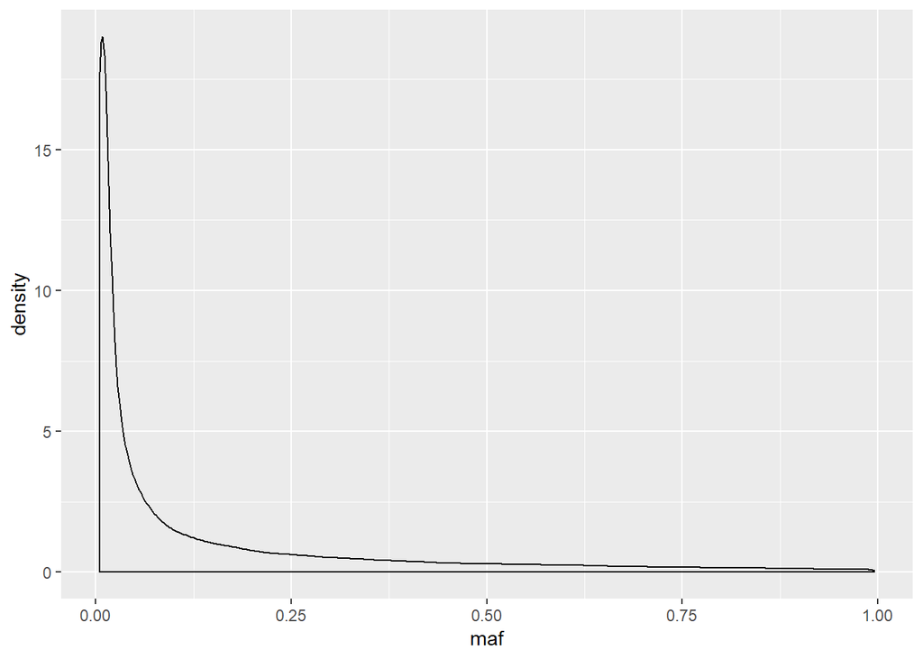

```r
maf_per_variant =  data_3L %>%
  mutate(maf = altc / total_l)

ggplot(maf_per_variant, aes(maf)) + geom_density()
```

#### Q: Visualize how the maf changes along the chromosome position

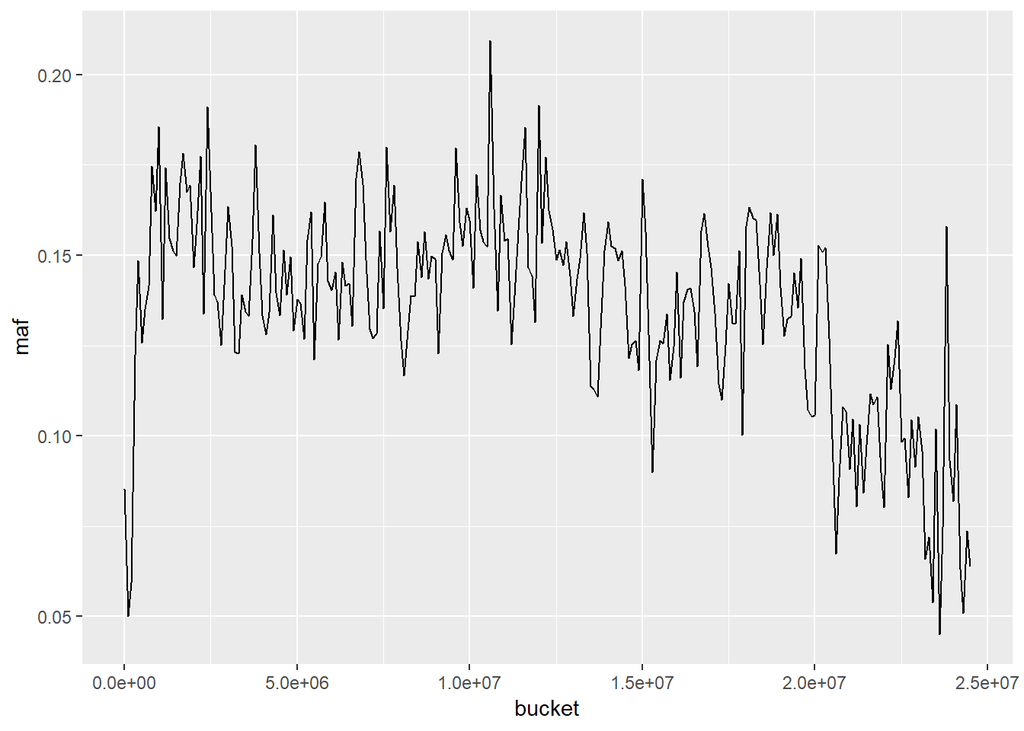

```r
maf_per_pos = maf_per_variant %>%
  group_by(pos) %>%
  summarise(maf = mean(maf))

bucket_cov = 10^5

binned_maf_per_pos = maf_per_pos %>%
  mutate(bucket = bucket_cov * pos%/%bucket_cov) %>%
  group_by(bucket) %>%
  summarise(maf = mean(maf))

ggplot(binned_maf_per_pos, aes(x = bucket, y = maf)) + geom_line()
```

#### Q: Visualize the distribution of coverage of variants (“cov”) that are genotyped in at least 95% of the lines

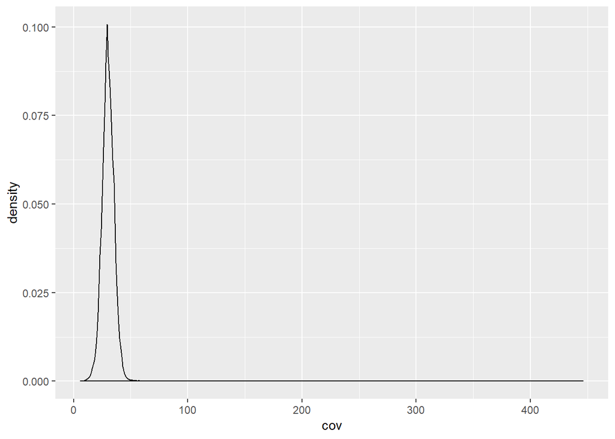

```r
ggplot(genotyped_95, aes(cov)) + geom_density()
```

#### Q: Visualize how the coverage changes along the chromosome position

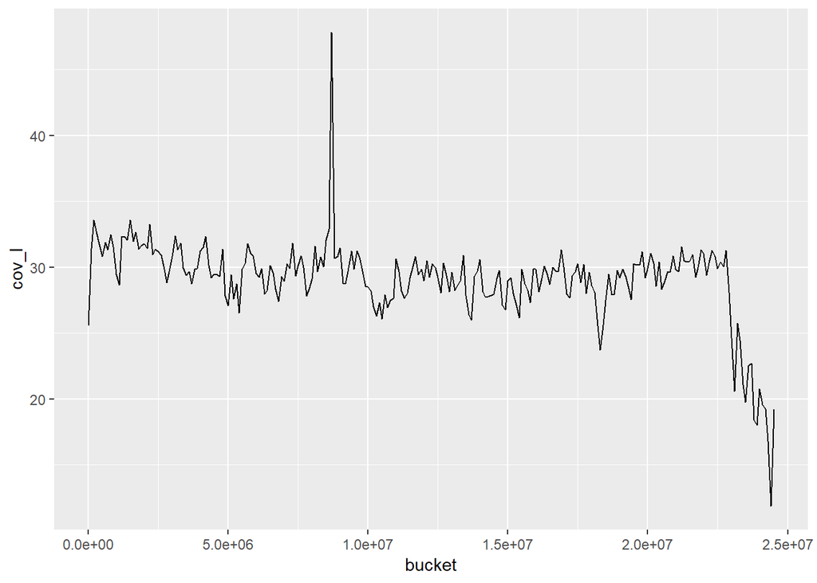

```r
bucket_cov = 10^5

cov_per_pos = data_3L %>%
  mutate(bucket = bucket_cov * pos%/%bucket_cov) %>%
  group_by(bucket) %>%
  summarise(cov_l = mean(cov))

ggplot(cov_per_pos, aes(x = bucket, y = cov_l)) + geom_line()
```

#### Q: How many loci are there of each type of variant in your dataset?

HINT: ?stringr::str_split_fixed and look at the “id” column

These are the variant types: INSertions, DELetions, Multiple Nucleotide Polymorphism, Single Nucleotide Polymorphism

```r
data_3L_varc = data_3L
data_3L_varc['var_class'] = str_split_fixed(data_3L['id'][[1]], "_", 3)[,3]

data_3L_varc %>%
  group_by(var_class) %>%
  summarise(n_loci = length(unique(pos)))
```

```
## # A tibble: 4 x 2
##   var_class n_loci
##   <chr>      <int>
## 1 DEL        65379
## 2 INS        36852
## 3 MNP         3066
## 4 SNP       896257
```

#### Q: How many rare and common variants are there?

We define a variant as either rare (minor allele frequency < 0.05) or common (minor allele frequency >= 0.05).

```r
maf_per_variant %>% count(maf < 0.05)
```

```
## # A tibble: 2 x 2
##   `maf < 0.05`      n
##   <lgl>         <int>
## 1 FALSE        444271
## 2 TRUE         557283
```

#### Q: Is there a statistical association between the different types of variants and the rare/common variants?

Do you think one of the variant classes have more rare alleles than other classes?

A: For each variant class VC: H0: VC does not have more rare alleles than other classes HA: ‘GREATER’: VC has more alleles than other classes.

```r
data_3L_varc['maf'] = maf_per_variant['maf']
pval_res = data_3L_varc %>%
  group_by(var_class) %>%
  summarise(vc = var_class[1],
            vc_rare = length(maf[maf<0.05]),
            vc_total = length(maf),
            other_rare = length((data_3L_varc %>% filter(var_class != vc & maf < 0.05))$maf),
            other_total = length((data_3L_varc %>% filter(var_class != vc))$maf),
            probr_vc = vc_rare / vc_total,
            probr_other = other_rare / other_total,
            p_value = binom.test(vc_rare, vc_total, p = probr_other, alternative = 'greater')[['p.value']])
```

A: We can see that INS and SNP are the ones that fit the null hypothesis. Del and MNP have more lower alleles:

```r
data.frame(pval_res$vc, pval_res$p_value)
```

```
##   pval_res.vc pval_res.p_value
## 1         DEL     0.000000e+00
## 2         INS     7.821940e-01
## 3         MNP     3.613244e-05
## 4         SNP     1.000000e+00
```

#### Q: If coverage was homogenous throughout the genome (by that we mean that on average the coverage is the same for any given position), what probability distribution is expected to capture well the coverage?

Poisson distribution

#### Q: Make goodness of fit test of the coverage data of your variants on chromosome 3L: is the theoretical distribution you just proposed a good fit for the data?

```r
cov_freq = data_3L %>% group_by(cov) %>% summarise(n = n())
c1 = data.frame(1, sum(cov_freq[1:11,]$n))
names(c1) = names(cov_freq)
c2 = data.frame(49, sum(cov_freq[45:63,]$n))
names(c2) = names(cov_freq)
c3 = merge(c1, cov_freq[12:44,], all = TRUE)
cov_freq = merge(c3, c2, all = TRUE)

total_cov = sum(cov_freq$n)
mean_cov = sum(cov_freq$cov * cov_freq$n) / total_cov
poisson_probs = (exp(1)^-mean_cov * mean_cov^cov_freq$cov)/factorial(cov_freq$cov)
expected_cp = total_cov * poisson_probs

#We need to group them a bit. the expected are too small
expected_cp = #c(sum(expected_cp[1:2]), expected_cp[11:49], sum(expected_cp[50:63]))
observed_cp = cov_freq$n #c(sum(cov_freq$n[1:10]), cov_freq$n[11:49], sum(cov_freq$n[50:63]))


xsqr_stat = sum(((observed_cp - expected_cp)^2) / expected_cp)
df = length(observed_cp) - 2
mean(1 - pchisq(xsqr_stat, df = df))
```

```
## [1] 1
```

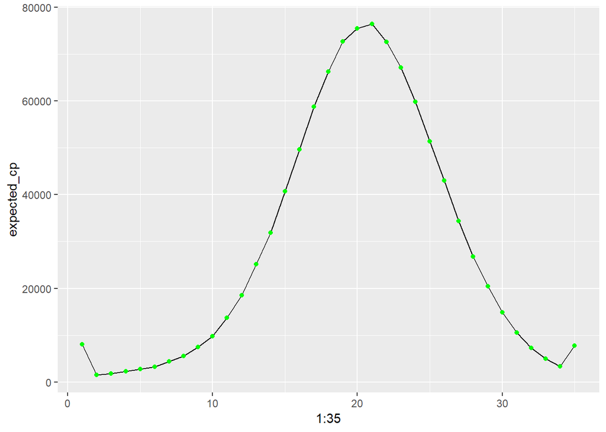

```r
ggplot() + geom_line(mapping = aes(x = 1:35, y = expected_cp)) +
   geom_point(mapping = aes(x = 1:35, y = observed_cp), color = 'green')
```

# From now on you should focus on a smaller region of chromosome 3L

So only pick 20000 SNPS. Ignore INSertions, DELetions, and MNPs.

```
end_pos = median(data_3L$pos)

f <- function(df, pos) {
  #print(df)

  tt <- df[1:1000,] %>%
    filter(chr == '3L' & pos < end_pos) %>%
    gather(key = "line", value = "genotype", starts_with("line")) %>%
    filter(genotype != '-') %>%
  {.}

  tt['var_class'] = str_split_fixed(tt['id'][[1]], "_", 3)[,3]
  #write_csv(tt, "../datasets/dgrp2.3L", append = TRUE) # Log progress to log file
  tt_res = tt %>% filter(var_class == 'SNP')
  return(tt_res)
}

data_file_path = "../datasets/dgrp2.tgeno"

first_2 = read_delim(data_file_path, delim = ' ', n_max = 2)

df_ <- read_delim_chunked(file = data_file_path,
                         callback = ListCallback$new(f),
                         chunk_size = 50000, guess_max = 100,
                         col_names = T, delim = " ", comment = "#",
                         progress = T)

df_ <- bind_rows(df_)
snps_3L <- df_
```

#### Q: Calculate the r squared association between each pair of neighboring SNPS (this association is also called “linkage disequilibrium”)

In population genetics, linkage disequilibrium is the non-random association of alleles at different loci in a given population.

Loci are said to be in linkage disequilibrium when the frequency of association of their different alleles is higher or lower than what would be expected if the loci were independent and associated randomly.

where $p_a$ is the frequency of allele $a$ at locus 1, $p_b$ is the frequency of allele $b$ at locus 2 and $p_{ab}$ is the frequency of haplotypes having allele $a$ at locus 1 and allele $b$ at locus 2 (Hill & Robertson, 1968).

Read more at wikipedia (if you like).

HINT: ?lead, tidy data HINT: only use cases where both SNPs are genotyped in the line (i.e. 0 or 2)

[output not shown]

```r
snps_3L['genotype2'] = lead(snps_3L$genotype, 1)
snps_3L = snps_3L %>% mutate(haplotype = paste(genotype, genotype2, sep = ' '))
```

```r
r2_summ = snps_3L %>%
  group_by(pos) %>%
  summarise(
    p0 = length(genotype[genotype == '2'])/length(genotype),
    p2 = length(genotype2[genotype2 == '2'])/length(genotype2),
    p02 = length(haplotype[haplotype == '2 2'])/length(haplotype),
    r2 = ((p02 - (p0 * p2))^2) / (p0*(1-p0)*p2*(1-p2))
  )
```

#### Q: Summarize average LD in distance bins and visualize how LD varies with the physical distance beween SNPs (measured in bp)

HINT:

```
dist <- 1:200
ifelse(dist > 10, 5 + 10 * dist %/% 10, dist )
```

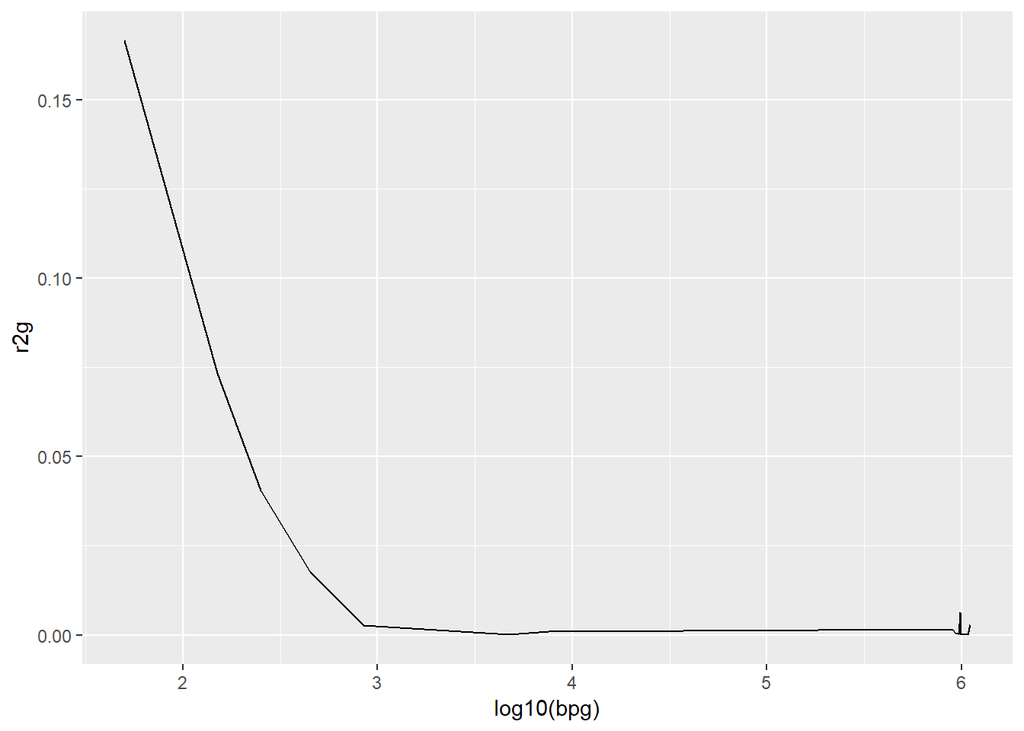

```r
bp = lead(r2_summ$pos, 1) - r2_summ$pos

r2_summ['bp'] = bp

r2_vs_dist = r2_summ %>%
  mutate(bpg = 50 + 100 * bp %/% 100) %>%
  group_by(bpg) %>%
  summarise(r2g = mean(r2, na.rm = TRUE))

ggplot(r2_vs_dist, aes(x = log10(bpg), y = r2g)) + geom_line()
```